# Transportia

## Análisis exploratorio de la flota de colectivos del AMBA

**Objetivo del proyecto:** reducir el *headway* y encontrar rutas más eficientes. **Objetivo de este notebook:** entender con qué datos contamos antes de modelar nada.

*Ciencia de datos aplicada (ITBA) — Entregable 2* *Equipo: Estudiante_1, Estudiante_2*

## Hoja de ruta

1. **Qué datos hay** y cuáles sirven al objetivo
2. **Cómo los cargamos** (ventana de 24 h, *stride*, dimensiones GTFS)
3. **Qué dice la muestra** — distribuciones, conteos, mapa de CABA
4. **Qué problemas detectamos** en la calidad de los datos
5. **Qué hicimos** para limpiarlos y transformarlos
6. **Cómo queda la muestra final** y qué se puede hacer con ella

> *Foco en describir, no en resolver.* La eficiencia de rutas y el cómputo de *headway* quedan para los próximos entregables.

## 1. Importación y carga de librerías

```python
import json
from pathlib import Path
from datetime import datetime, timezone

import numpy as np
import pandas as pd
import matplotlib.pyplot as plt
import seaborn as sns

sns.set(style='whitegrid')
plt.rcParams.update({
    'figure.figsize':   (11, 6),
    'font.size':        12,
    'axes.titlesize':   15,
    'axes.titleweight': 'bold',
    'axes.labelsize':   12,
    'xtick.labelsize':  11,
    'ytick.labelsize':  11,
    'legend.fontsize':  11,
    'figure.titlesize': 16,
    'figure.titleweight': 'bold',
})
pd.set_option('display.max_columns', 60)
pd.set_option('display.width', 140)

DATA = Path('..') / 'data'
TZ = 'America/Argentina/Buenos_Aires'

RNG = np.random.default_rng(42)
```

## 2. Contexto y objetivo

> El AMBA mueve millones de personas por día en colectivo. Cada vehículo emite un *fix* GPS cada ~30 s vía la API de Transporte de Buenos Aires.

**Lo que queremos resolver (más adelante):**

- **Reducir el *headway*** — el tiempo que un pasajero espera entre dos colectivos sucesivos de la misma línea.
- **Detectar trazados ineficientes** — comparar el recorrido planificado contra el observado.

**Lo que hace este notebook:**

- Inventariar las fuentes en `data/` y decidir cuáles aportan al objetivo.
- Armar un DataFrame único con la mejor ventana de 24 h disponible.
- Limpiar, transformar, describir.
- Dejar todo listo para los entregables siguientes.

Período recolectado: **2026-04-18 al 2026-04-25** (7 días).

## 3. Inventario de fuentes

> *44 GB de datos en bruto. ¿Cuáles tocamos?*

Recorremos los subdirectorios de `data/` y reportamos volumen y formato. La decisión de incluir/excluir va en la celda siguiente.

```python
def leaf_dirs(root: Path):
    for p in root.rglob('*'):
        if p.is_dir() and not any(c.is_dir() for c in p.iterdir()):
            yield p

rows = []
for d in leaf_dirs(DATA):
    files = [f for f in d.iterdir() if f.is_file()]
    if not files:
        continue
    sizes = [f.stat().st_size for f in files]
    rows.append({
        'ruta': str(d.relative_to(DATA)),
        'n_archivos': len(files),
        'tamaño_MB': round(sum(sizes)/1e6, 1),
        'extensión': files[0].suffix.lstrip('.'),
    })
inventario = pd.DataFrame(rows).sort_values('tamaño_MB', ascending=False).reset_index(drop=True)
inventario
```

|  | ruta | n_archivos | tamaño_MB | extensión |
| --- | --- | --- | --- | --- |
| 0 | colectivos/vehicle_positions | 3601 | 31687.8 | json |
| 1 | colectivos/vehicle_positions_simple | 3403 | 4281.0 | json |
| 2 | colectivos/feed_gtfs/20260425_025706 | 7 | 1463.1 | txt |
| 3 | colectivos/feed_gtfs/20260418_141433 | 7 | 1463.1 | csv |
| 4 | colectivos/feed_gtfs/20260418_210252 | 7 | 1463.1 | txt |
| 5 | colectivos/feed_gtfs/20260424_145308 | 7 | 1463.1 | txt |
| 6 | colectivos/feed_gtfs/20260424_205439 | 7 | 1463.1 | txt |
| 7 | colectivos/feed_gtfs/20260425_085624 | 7 | 1463.1 | txt |
| 8 | transito/v1/semaforos | 363 | 300.7 | json |
| 9 | colectivos/service_alerts | 904 | 89.3 | json |
| 10 | colectivos/feed_gtfs_frequency/20260424_205149 | 10 | 48.7 | txt |
| 11 | colectivos/feed_gtfs_frequency/20260418_210205 | 10 | 48.7 | txt |
| 12 | colectivos/feed_gtfs_frequency/20260419_030204 | 10 | 48.7 | txt |
| 13 | colectivos/feed_gtfs_frequency/20260425_025212 | 10 | 48.7 | txt |
| 14 | colectivos/feed_gtfs_frequency/20260424_145154 | 10 | 48.7 | txt |
| 15 | colectivos/feed_gtfs_frequency/20260425_145157 | 10 | 48.7 | txt |
| 16 | colectivos/feed_gtfs_frequency/20260418_141208 | 10 | 48.7 | csv |
| 17 | colectivos/feed_gtfs_frequency/20260425_085200 | 10 | 48.7 | txt |
| 18 | datos/movilidad/transito/semana_tipica | 4 | 1.4 | json |
| 19 | datos/movilidad/transito/mensual | 45 | 0.0 | csv |
| 20 | datos/movilidad/transito/hourly | 33 | 0.0 | json |
| 21 | datos/movilidad/transporte_publico/mensual | 45 | 0.0 | csv |
| 22 | datos/movilidad/transporte_publico/daily | 33 | 0.0 | json |
| 23 | datos/movilidad/transporte_publico/semana_tipica | 4 | 0.0 | json |

### Decisiones de alcance

| Fuente | Decisión | Por qué |
| --- | --- | --- |
| `colectivos/vehicle_positions_simple` | **Tabla de hechos** | Pings cada 30 s, formato plano, todo lo necesario para describir el movimiento. |
| `colectivos/vehicle_positions` | Solo esquema | Mismas pings con campos extra (`occupancy_status`, `current_stop_sequence`...). 30 GB; los traemos cuando hagan falta. |
| `colectivos/feed_gtfs` | **Dimensiones** | Rutas, viajes, paradas, *shapes*. Sin esto, los `route_id` no significan nada. |
| `colectivos/feed_gtfs_frequency` | **Solo `frequencies.txt`** | Define el headway *programado* — la referencia futura. |
| `colectivos/service_alerts` | Conteo agregado | Contexto, no granularidad de ping. |
| `transito/v1/*` | **Excluir** | Sobre tránsito vehicular general, no sobre colectivos. |
| `datos/movilidad/*` | **Excluir** | Agregados horarios — granularidad insuficiente para *headway* a nivel de parada. |

## 4. Carga de datos

### 4.1 Elegir la ventana de 24 h

Cada archivo se llama `YYYYMMDD_HHMMSS.json` (hora local de recolección). Buscamos la ventana contigua de 24 h con **mayor cobertura** — la que tiene más archivos consecutivos.

```python
VP_SIMPLE = DATA / 'colectivos' / 'vehicle_positions_simple'

def fname_to_dt(p: Path) -> pd.Timestamp:
    return pd.to_datetime(p.stem, format='%Y%m%d_%H%M%S').tz_localize(TZ)

vp_files = sorted(VP_SIMPLE.glob('*.json'))
vp_dts = pd.Series([fname_to_dt(p) for p in vp_files], name='dt')

print(f'Archivos vp_simple: {len(vp_files):,}')
print(f'Rango: {vp_dts.min()}  →  {vp_dts.max()}')
print(f'Span total: {vp_dts.max() - vp_dts.min()}')
```

```
Archivos vp_simple: 3,403
Rango: 2026-04-18 14:12:18-03:00  →  2026-04-25 14:51:28-03:00
Span total: 7 days 00:39:10
```

```python
WINDOW = pd.Timedelta(hours=24)

best_start, best_count = None, -1
for ts in vp_dts:
    end = ts + WINDOW
    n = ((vp_dts >= ts) & (vp_dts < end)).sum()
    if n > best_count:
        best_start, best_count = ts, n

WIN_START = best_start
WIN_END = best_start + WINDOW
mask = (vp_dts >= WIN_START) & (vp_dts < WIN_END)
files_24h = [p for p, m in zip(vp_files, mask) if m]

print(f'Ventana elegida: {WIN_START}  →  {WIN_END}')
print(f'Archivos en ventana: {len(files_24h):,}  (cadencia esperada 2880 a 30s)')
```

```
Ventana elegida: 2026-04-24 14:52:03-03:00  →  2026-04-25 14:52:03-03:00
Archivos en ventana: 2,678  (cadencia esperada 2880 a 30s)
```

### 4.2 Leer `vehicle_positions_simple`

Aplicamos un *stride* sobre los archivos para que el notebook corra en una laptop. Cada archivo es un *snapshot* de la flota completa: submuestrear archivos baja la cadencia (30 s → 30 × stride s) **sin perder cobertura** de líneas ni vehículos.

```python
STRIDE = 4
files_used = files_24h[::STRIDE]
print(f'Archivos a leer: {len(files_used):,}  (cadencia efectiva {30*STRIDE} s)')

records = []
for p in files_used:
    with p.open('r', encoding='utf-8') as fh:
        snap = json.load(fh)
    file_dt = fname_to_dt(p)
    for r in snap:
        r['_file_dt'] = file_dt
        records.append(r)

df_raw = pd.DataFrame.from_records(records)
print(f'Filas: {len(df_raw):,}  Columnas: {df_raw.shape[1]}')
df_raw.head(3)
```

```
Archivos a leer: 670  (cadencia efectiva 120 s)
```

```
Filas: 2,498,389  Columnas: 13
```

|  | route_id | latitude | longitude | speed | timestamp | id | direction | agency_name | agency_id | route_short_name | tip_id | trip_headsign | _file_dt |
| --- | --- | --- | --- | --- | --- | --- | --- | --- | --- | --- | --- | --- | --- |
| 0 | 764 | -34.62141 | -58.368300 | 9.166666 | 1777042242 | 1879 | 0 | MICRO OMNIBUS QUILMES S.A.C.I. Y F. | 72 | 159C | 395755-1 | a B° Don Orione x A.Alsina | 2026-04-24 14:52:03-03:00 |
| 1 | 740 | -34.78997 | -58.217580 | 0.000000 | 1777042248 | 1892 | 1 | MICROOMNIBUS CUARENTA Y CINCO S.A.C.I.F. | 83 | 154A | 166989-1 | Ramal 1 - a San Miguel | 2026-04-24 14:52:03-03:00 |
| 2 | 751 | -34.78901 | -58.163155 | 10.000000 | 1777042214 | 1905 | 1 | LA PRIMERA DE GRAND BOURG S.A. | 132 | 315A | 399713-1 | a Gral Paz X Ramos Mejia | 2026-04-24 14:52:03-03:00 |

### 4.3 El feed *completo* (sin cargarlo)

Inspeccionamos un único archivo de `vehicle_positions/` para documentar campos extra que el feed *simple* no expone. Estos campos serán clave para *headway* (entrada/salida de paradas, ocupación), pero no entran en este EDA.

```python
VP_FULL = DATA / 'colectivos' / 'vehicle_positions'
sample_full = next(iter(sorted(VP_FULL.glob('*.json'))))
with sample_full.open('r', encoding='utf-8') as fh:
    full = json.load(fh)

first_vehicle = full['_entity'][0]['_vehicle']
extra_fields = {
    'current_status': first_vehicle.get('_current_status'),
    'current_stop_sequence': first_vehicle.get('_current_stop_sequence'),
    'stop_id': first_vehicle.get('_stop_id'),
    'occupancy_status': first_vehicle.get('_occupancy_status'),
    'congestion_level': first_vehicle.get('_congestion_level'),
    'odometer': first_vehicle['_position'].get('_odometer'),
    'bearing': first_vehicle['_position'].get('_bearing'),
}
pd.Series(extra_fields, name='valor_de_ejemplo').to_frame()
```

|  | valor_de_ejemplo |
| --- | --- |
| current_status | 2 |
| current_stop_sequence | 41 |
| stop_id | 6568125169 |
| occupancy_status | 0 |
| congestion_level | 0 |
| odometer | 65887 |
| bearing | 0 |

### 4.4 Dimensiones GTFS estáticas

Tomamos el snapshot GTFS más cercano al **centro** de la ventana (no al inicio: minimiza claves huérfanas). Omitimos `stop_times.txt` (~1.4 GB) — innecesario para describir.

```python
def snap_dt(p): return pd.to_datetime(p.name, format='%Y%m%d_%H%M%S').tz_localize(TZ)

GTFS = DATA / 'colectivos' / 'feed_gtfs'
snapshots = [p for p in GTFS.iterdir() if p.is_dir()]
mid = WIN_START + WINDOW / 2
snap = min(snapshots, key=lambda s: abs(snap_dt(s) - mid))
print(f'Snapshot GTFS más cercano al centro de la ventana: {snap.name}')

routes = pd.read_csv(snap / 'routes.txt', dtype=str)
trips = pd.read_csv(snap / 'trips.txt', dtype=str)
stops = pd.read_csv(snap / 'stops.txt', dtype=str)
agency = pd.read_csv(snap / 'agency.txt', dtype=str)

GTFS_FREQ = DATA / 'colectivos' / 'feed_gtfs_frequency'
freq_snap = min((p for p in GTFS_FREQ.iterdir() if p.is_dir()),
                key=lambda s: abs(snap_dt(s) - mid))
frequencies = pd.read_csv(freq_snap / 'frequencies.txt', dtype=str)

for name, d in [('routes', routes), ('trips', trips), ('stops', stops),
                ('agency', agency), ('frequencies', frequencies)]:
    print(f'{name:<13} {d.shape[0]:>8,} filas   {list(d.columns)}')
```

```
Snapshot GTFS más cercano al centro de la ventana: 20260425_025706
```

```
routes           1,076 filas   ['route_id', 'agency_id', 'route_short_name', 'route_long_name', 'route_desc', 'route_type']
trips          453,075 filas   ['route_id', 'service_id', 'trip_id', 'trip_headsign', 'trip_short_name', 'direction_id', 'block_id', 'shape_id', 'exceptional']
stops           43,201 filas   ['stop_id', 'stop_code', 'stop_name', 'stop_lat', 'stop_lon']
agency             193 filas   ['agency_id', 'agency_name', 'agency_url', 'agency_timezone', 'agency_lang', 'agency_phone']
frequencies     26,237 filas   ['trip_id', 'start_time', 'end_time', 'headway_secs', 'exact_times']
```

## 5. ¿Qué tenemos en el DataFrame?

Una fila = una observación de posición de un vehículo en un instante.

| Variable | Tipo | Significado |
| --- | --- | --- |
| `route_id`, `route_short_name` | categórica | Línea (id GTFS y nombre comercial). |
| `agency_id`, `agency_name` | categórica | Empresa concesionaria. |
| `direction` | categórica binaria | Sentido (ida / vuelta). |
| `tip_id`, `trip_headsign` | categórica | Viaje específico y cabecera al pasajero. |
| `id` | categórica | Vehículo físico. |
| `latitude`, `longitude` | numérica | Posición WGS84. AMBA: lat ∈ [−35.0, −34.3], lon ∈ [−59.0, −58.0]. |
| `speed` | numérica | Velocidad GPS en m/s. |
| `timestamp` | temporal | Fix GPS (epoch). |
| `_file_dt` | temporal | Instante de recolección por nuestro colector. |

## 6. ¿Qué dice la muestra?

Recorremos: panorama general → faltantes → distribuciones → conteos → cobertura temporal → cobertura espacial → correlación.

```python
df_raw.info()
```

```
<class 'pandas.DataFrame'>
RangeIndex: 2498389 entries, 0 to 2498388
Data columns (total 13 columns):
 #   Column            Dtype
---  ------            -----
 0   route_id          str
 1   latitude          float64
 2   longitude         float64
 3   speed             float64
 4   timestamp         int64
 5   id                str
 6   direction         int64
 7   agency_name       str
 8   agency_id         int64
 9   route_short_name  str
 10  tip_id            str
 11  trip_headsign     str
 12  _file_dt          datetime64[us, America/Argentina/Buenos_Aires]
dtypes: datetime64[us, America/Argentina/Buenos_Aires](1), float64(3), int64(3), str(6)
memory usage: 247.8 MB
```

```python
df_raw.describe(include='all').T
```

|  | count | unique | top | freq | mean | min | 25% | 50% | 75% | max | std |
| --- | --- | --- | --- | --- | --- | --- | --- | --- | --- | --- | --- |
| route_id | 2498389 | 1495 | 1705 | 17405 | NaN | NaN | NaN | NaN | NaN | NaN | NaN |
| latitude | 2498389.0 | NaN | NaN | NaN | -34.496043 | -41.18897 | -34.70894 | -34.62875 | -34.56407 | -26.75823 | 1.340056 |
| longitude | 2498389.0 | NaN | NaN | NaN | -58.79468 | -71.56252 | -58.65322 | -58.494934 | -58.39888 | -56.67697 | 1.567983 |
| speed | 2498389.0 | NaN | NaN | NaN | 4.738082 | 0.0 | 0.0 | 3.611111 | 7.777777 | 34.444443 | 5.054036 |
| timestamp | 2498389.0 | NaN | NaN | NaN | 1777079774.913562 | 1777026452.0 | 1777058324.0 | 1777071828.0 | 1777109038.0 | 1777128580.0 | 26806.438392 |
| id | 2498389 | 12279 | 31447 | 641 | NaN | NaN | NaN | NaN | NaN | NaN | NaN |
| direction | 2498389.0 | NaN | NaN | NaN | 0.491153 | 0.0 | 0.0 | 0.0 | 1.0 | 1.0 | 0.499922 |
| agency_name | 2498389 | 126 | LA NUEVA METROPOL S.A. | 104449 | NaN | NaN | NaN | NaN | NaN | NaN | NaN |
| agency_id | 2498389.0 | NaN | NaN | NaN | 89.8963 | 2.0 | 40.0 | 70.0 | 127.0 | 468.0 | 84.072421 |
| route_short_name | 2498389 | 808 | 242C | 26520 | NaN | NaN | NaN | NaN | NaN | NaN | NaN |
| tip_id | 2498389 | 65120 | 299888-1 | 1261 | NaN | NaN | NaN | NaN | NaN | NaN | NaN |
| trip_headsign | 2487268 | 818 | a Constitución | 40334 | NaN | NaN | NaN | NaN | NaN | NaN | NaN |
| _file_dt | 2498389 | NaN | NaN | NaN | 2026-04-25 01:19:49.353238-03:00 | 2026-04-24 14:52:03-03:00 | 2026-04-24 19:20:20-03:00 | 2026-04-24 23:08:59-03:00 | 2026-04-25 09:24:57-03:00 | 2026-04-25 14:50:56-03:00 | NaN |

### 6.1 Faltantes

> *Spoiler:* prácticamente nada.

```python
nulos = df_raw.isnull().sum().to_frame('n_nulos')
nulos['pct'] = (nulos['n_nulos'] / len(df_raw) * 100).round(3)
nulos.sort_values('n_nulos', ascending=False)
```

|  | n_nulos | pct |
| --- | --- | --- |
| trip_headsign | 11121 | 0.445 |
| latitude | 0 | 0.000 |
| longitude | 0 | 0.000 |
| speed | 0 | 0.000 |
| route_id | 0 | 0.000 |
| timestamp | 0 | 0.000 |
| id | 0 | 0.000 |
| agency_name | 0 | 0.000 |
| direction | 0 | 0.000 |
| agency_id | 0 | 0.000 |
| route_short_name | 0 | 0.000 |
| tip_id | 0 | 0.000 |
| _file_dt | 0 | 0.000 |

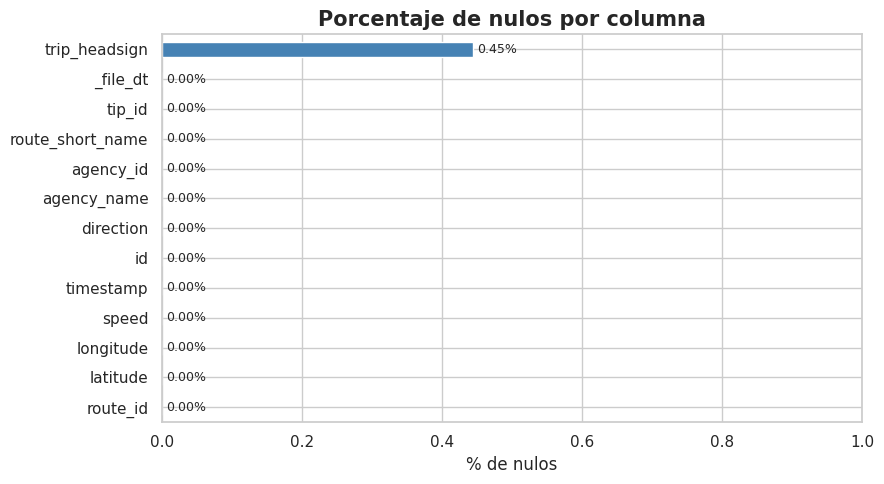

```python
pct_nulos = (df_raw.isnull().mean() * 100).sort_values()

fig, ax = plt.subplots(figsize=(9, 5))
pct_nulos.plot.barh(ax=ax, color='steelblue')
ax.set_xlabel('% de nulos')
ax.set_title('Porcentaje de nulos por columna')
ax.bar_label(ax.containers[0], fmt='%.2f%%', padding=3, fontsize=9)
ax.set_xlim(0, max(pct_nulos.max() * 1.25, 1))
plt.tight_layout()
plt.show()
```

### 6.2 Distribuciones de variables numéricas

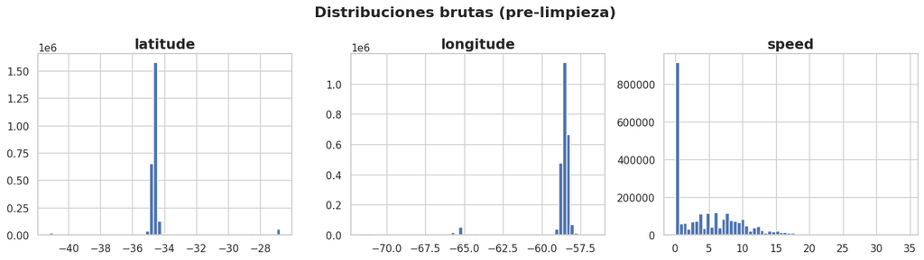

```python
num_cols = ['latitude', 'longitude', 'speed']
df_raw[num_cols].hist(bins=60, figsize=(14, 4), layout=(1, 3))
plt.suptitle('Distribuciones brutas (pre-limpieza)')
plt.tight_layout()
plt.show()
```

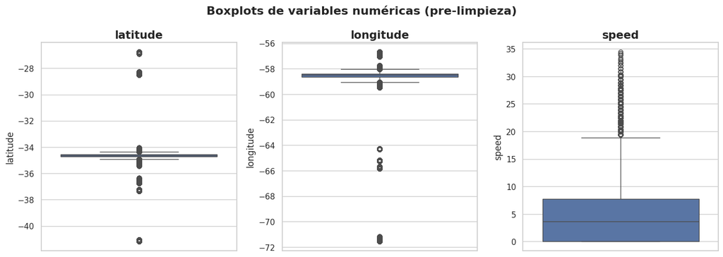

```python
fig, axes = plt.subplots(1, 3, figsize=(14, 5))
for ax, c in zip(axes, num_cols):
    sns.boxplot(y=df_raw[c], ax=ax)
    ax.set_title(c)
plt.suptitle('Boxplots de variables numéricas (pre-limpieza)')
plt.tight_layout()
plt.show()
```

### 6.3 ¿Quién manda? — top empresas y líneas

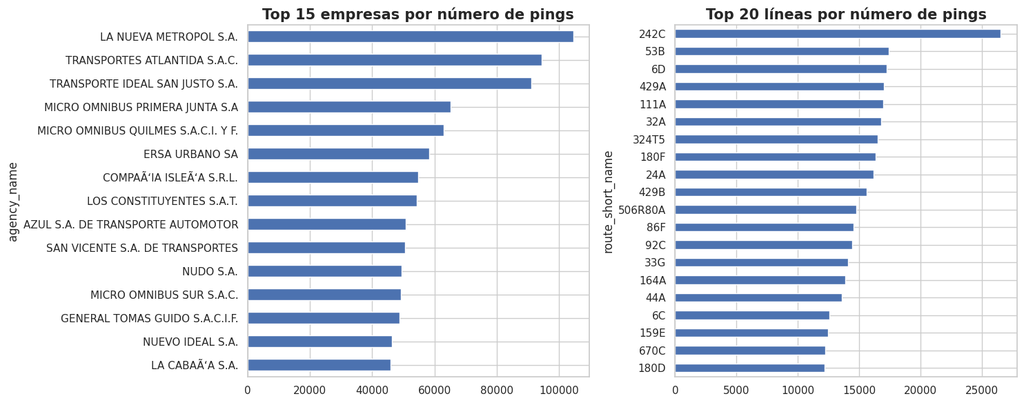

```python
fig, axes = plt.subplots(1, 2, figsize=(15, 6))
df_raw['agency_name'].value_counts().head(15).plot.barh(ax=axes[0])
axes[0].set_title('Top 15 empresas por número de pings')
axes[0].invert_yaxis()
df_raw['route_short_name'].value_counts().head(20).plot.barh(ax=axes[1])
axes[1].set_title('Top 20 líneas por número de pings')
axes[1].invert_yaxis()
plt.tight_layout()
plt.show()
```

```python
df_raw['direction'].value_counts(dropna=False).rename_axis('direction').to_frame('n_pings')
```

| direction | n_pings |
| --- | --- |
| 0 | 1271297 |
| 1 | 1227092 |

### 6.4 Cobertura temporal

Pings por minuto durante la ventana. **Caídas a cero = huecos del colector.**

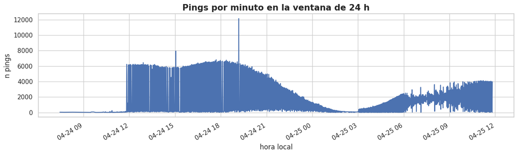

```python
ts_local = pd.to_datetime(df_raw['timestamp'], unit='s', utc=True).dt.tz_convert(TZ)
pings_por_min = ts_local.dt.floor('min').value_counts().sort_index()

fig, ax = plt.subplots(figsize=(13, 4))
pings_por_min.plot(ax=ax)
ax.set_title('Pings por minuto en la ventana de 24 h')
ax.set_ylabel('n pings')
ax.set_xlabel('hora local')
plt.tight_layout()
plt.show()
```

### 6.5 Cobertura espacial — todo el AMBA

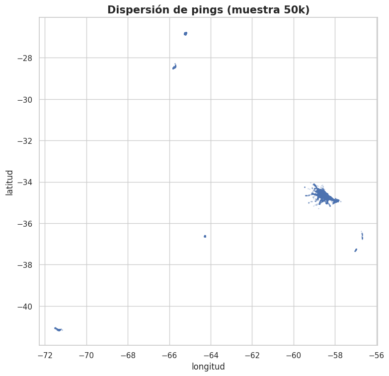

```python
muestra = df_raw.sample(min(50_000, len(df_raw)), random_state=42)
fig, ax = plt.subplots(figsize=(8, 8))
ax.scatter(muestra['longitude'], muestra['latitude'], s=1, alpha=0.2)
ax.set_title('Dispersión de pings (muestra 50k)')
ax.set_xlabel('longitud')
ax.set_ylabel('latitud')
ax.set_aspect('equal')
plt.tight_layout()
plt.show()
```

### 6.6 Zoom sobre CABA con basemap

`lat ∈ [-34.71, -34.52]`, `lon ∈ [-58.55, -58.33]`. Las concentraciones lineales rojas trazan los corredores troncales (Rivadavia, 9 de Julio, Corrientes, Santa Fe, Cabildo).

[figure not shown]

```python
import contextily as cx

CABA_LAT = (-34.71, -34.52)
CABA_LON = (-58.55, -58.33)
caba = df_raw[df_raw['latitude'].between(*CABA_LAT) & df_raw['longitude'].between(*CABA_LON)]
muestra_caba = caba.sample(min(80_000, len(caba)), random_state=42)

fig, ax = plt.subplots(figsize=(10, 10))
ax.scatter(muestra_caba['longitude'], muestra_caba['latitude'],
           s=2, alpha=0.25, c='crimson', linewidths=0)
ax.set_xlim(*CABA_LON)
ax.set_ylim(*CABA_LAT)
ax.set_aspect('equal')
cx.add_basemap(ax, crs='EPSG:4326', source=cx.providers.OpenStreetMap.Mapnik, zoom=12)
ax.set_title('Densidad de pings de colectivos sobre CABA')
ax.set_xlabel('longitud')
ax.set_ylabel('latitud')
plt.tight_layout()
plt.show()
```

### 6.7 Correlación entre numéricas

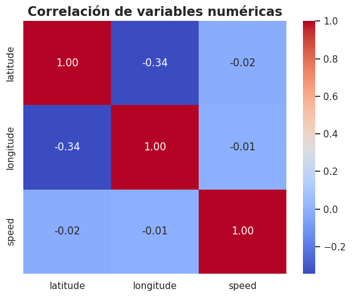

```python
fig, ax = plt.subplots(figsize=(6, 5))
sns.heatmap(df_raw[num_cols].corr(), annot=True, fmt='.2f', cmap='coolwarm', ax=ax)
ax.set_title('Correlación de variables numéricas')
plt.tight_layout()
plt.show()
```

## 7. ¿Qué problemas tienen los datos?

Siete hallazgos surgidos del EDA y del conocimiento de dominio:

```python
ts_aux = pd.to_datetime(df_raw['timestamp'], unit='s', utc=True).dt.tz_convert(TZ)
drift_s = (df_raw['_file_dt'] - ts_aux).dt.total_seconds()

diag = {
    'speed_>_30_m/s':       int((df_raw['speed'] > 30).sum()),
    'speed_==_0':           int((df_raw['speed'] == 0).sum()),
    'lat_fuera_AMBA':       int(((df_raw['latitude'] < -35.0) | (df_raw['latitude'] > -34.3)).sum()),
    'lon_fuera_AMBA':       int(((df_raw['longitude'] < -59.0) | (df_raw['longitude'] > -58.0)).sum()),
    'dup_(id,timestamp)':   int(df_raw.duplicated(subset=['id', 'timestamp']).sum()),
    'drift_GPS_>_10_min':   int((drift_s.abs() > 600).sum()),
    'route_id_huérfano':    int((~df_raw['route_id'].isin(routes['route_id'])).sum()),
    'trip_id_huérfano':     int((~df_raw['tip_id'].isin(trips['trip_id'])).sum()),
}
res = pd.Series(diag, name='n_filas').to_frame()
res['pct'] = (res['n_filas'] / len(df_raw) * 100).round(3)

print('Drift GPS (segundos): mediana = {:.0f}  IQR = [{:.0f}, {:.0f}]  máx = {:.0f}'
      .format(drift_s.median(), drift_s.quantile(0.25), drift_s.quantile(0.75), drift_s.abs().max()))
res
```

```
Drift GPS (segundos): mediana = 10873  IQR = [10860, 10885]  máx = 35791
```

|  | n_filas | pct |
| --- | --- | --- |
| speed_>_30_m/s | 38 | 0.002 |
| speed_==_0 | 819902 | 32.817 |
| lat_fuera_AMBA | 116585 | 4.666 |
| lon_fuera_AMBA | 172708 | 6.913 |
| dup_(id,timestamp) | 152603 | 6.108 |
| drift_GPS_>_10_min | 2498389 | 100.000 |
| route_id_huérfano | 1755931 | 70.283 |
| trip_id_huérfano | 0 | 0.000 |

## 8. Limpieza

| Acción | Qué hacemos | Por qué |
| --- | --- | --- |
| Renombrar | `tip_id` → `trip_id` | Estándar GTFS. |
| Convertir | `timestamp` → `datetime` con TZ | Manipulable y comparable. |
| Filtrar | `speed ∈ [0, 30] m/s` | Velocidades imposibles. |
| Filtrar | Coordenadas dentro de AMBA | GPS espurio. |
| Filtrar | Filas sin `route_id` | Sin línea, no sirven. |
| Deduplicar | `(id, timestamp)` único | Polls que no traen fix nuevo. |
| Conservar | `speed == 0`, `trip_headsign` nulos | Semánticamente válidos. |
| **No** imputar | Ninguna columna crítica tiene nulos masivos | Imputación injustificada. |

```python
df = df_raw.rename(columns={'tip_id': 'trip_id'}).copy()
df['ts'] = pd.to_datetime(df['timestamp'], unit='s', utc=True).dt.tz_convert(TZ)

n0 = len(df)
df = df[df['speed'].between(0, 30)]
df = df[df['latitude'].between(-35.0, -34.3) & df['longitude'].between(-59.0, -58.0)]
df = df.dropna(subset=['route_id'])
df = df.drop_duplicates(subset=['id', 'timestamp']).reset_index(drop=True)
n1 = len(df)
print(f'Filas antes:  {n0:,}')
print(f'Filas después: {n1:,}  ({(n1-n0)/n0*100:+.2f}%)')
```

```
Filas antes:  2,498,389
Filas después: 2,173,050  (-13.02%)
```

## 9. Transformaciones

- Categóricas: `agency_name`, `route_short_name`, `trip_headsign`, `direction` (con etiquetas *ida / vuelta*).
- Temporales: `ts` con TZ, `hour`, `dow`.
- Derivada: `gap_s` — segundos entre dos pings consecutivos del **mismo vehículo**. *No es el headway*, pero sirve como proxy de continuidad de la traza.

```python
df['agency_name'] = pd.Categorical(df['agency_name'])
df['route_short_name'] = pd.Categorical(df['route_short_name'])
df['trip_headsign'] = pd.Categorical(df['trip_headsign'])
df['direction'] = pd.Categorical(df['direction'].map({0: 'ida', 1: 'vuelta'}),
                                 categories=['ida', 'vuelta'], ordered=False)

df = df.sort_values(['id', 'ts'])
df['gap_s'] = df.groupby('id', observed=True)['ts'].diff().dt.total_seconds()
df['hour'] = df['ts'].dt.hour.astype('int8')
df['dow'] = df['ts'].dt.day_name()

df.dtypes
```

```
route_id                                                       str
latitude                                                   float64
longitude                                                  float64
speed                                                      float64
timestamp                                                    int64
id                                                             str
direction                                                 category
agency_name                                               category
agency_id                                                    int64
route_short_name                                          category
trip_id                                                        str
trip_headsign                                             category
_file_dt            datetime64[us, America/Argentina/Buenos_Aires]
ts                   datetime64[s, America/Argentina/Buenos_Aires]
gap_s                                                      float64
hour                                                          int8
dow                                                            str
dtype: object
```

## 10. Estadísticos de la muestra final

Media, mediana, varianza, IQR — y los boxplots correspondientes.

```python
num_final = ['latitude', 'longitude', 'speed', 'gap_s']
stats = df[num_final].agg(['mean', 'median', 'var', 'std',
                            lambda s: s.quantile(0.25),
                            lambda s: s.quantile(0.75),
                            'min', 'max']).T
stats.columns = ['media', 'mediana', 'varianza', 'desv_est', 'q25', 'q75', 'min', 'max']
stats.round(4)
```

|  | media | mediana | varianza | desv_est | q25 | q75 | min | max |
| --- | --- | --- | --- | --- | --- | --- | --- | --- |
| latitude | -34.6326 | -34.6270 | 1.140000e-02 | 0.1066 | -34.6989 | -34.5716 | -35.0 | -34.3 |
| longitude | -58.5156 | -58.4850 | 2.520000e-02 | 0.1587 | -58.6224 | -58.4010 | -59.0 | -58.0 |
| speed | 4.7912 | 3.6111 | 2.566780e+01 | 5.0663 | 0.0000 | 8.0556 | 0.0 | 30.0 |
| gap_s | 292.9847 | 120.0000 | 3.899321e+06 | 1974.6697 | 120.0000 | 150.0000 | 8.0 | 86334.0 |

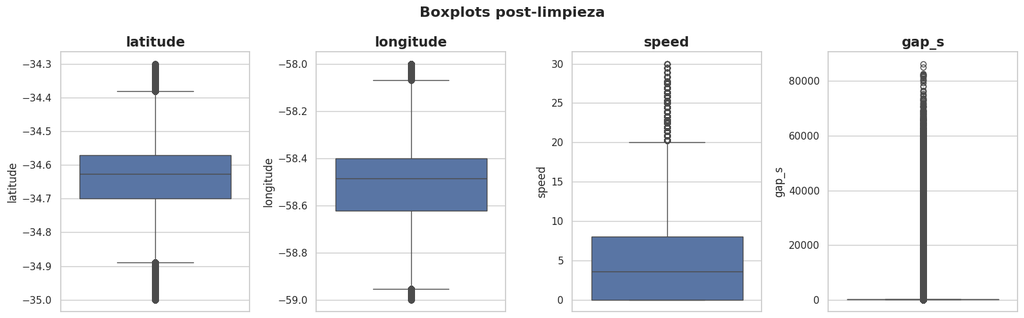

```python
fig, axes = plt.subplots(1, 4, figsize=(16, 5))
for ax, c in zip(axes, num_final):
    sns.boxplot(y=df[c], ax=ax)
    ax.set_title(c)
plt.suptitle('Boxplots post-limpieza')
plt.tight_layout()
plt.show()
```

```python
resumen = {
    'n_filas': len(df),
    'n_vehiculos': df['id'].nunique(),
    'n_rutas': df['route_id'].nunique(),
    'n_empresas': df['agency_id'].nunique(),
    'span_inicio': df['ts'].min(),
    'span_fin': df['ts'].max(),
    'span': df['ts'].max() - df['ts'].min(),
}
pd.Series(resumen, name='valor').to_frame()
```

|  | valor |
| --- | --- |
| n_filas | 2173050 |
| n_vehiculos | 11741 |
| n_rutas | 1259 |
| n_empresas | 123 |
| span_inicio | 2026-04-24 07:27:32-03:00 |
| span_fin | 2026-04-25 11:49:40-03:00 |
| span | 1 days 04:22:08 |

## 11. Conclusiones

**La muestra:**

1. El `timestamp` viene **3 h corrido** — bug del proveedor, documentado y *no* bloqueante.
2. El `route_id` del feed RT **no matchea 1:1** con el GTFS estático. Habrá que joinear por `(route_short_name, agency_id)` o reconstruir el mapeo.
3. Velocidad mediana **3.6 m/s = 13 km/h** — coherente con circulación urbana incluyendo paradas.

**Próximos pasos (fuera de este notebook):**

- **Headway observado** → pings × `stops` (espacial) × `stop_times` (temporal).
- **Eficiencia de ruta** → traza GPS vs `shapes.txt`, medir desvíos y detenciones.
- **Patrones por día de la semana** → ampliar la ventana a los 7 días disponibles.

> El DataFrame `df` queda servido para todo lo anterior.